# HW3

Annie

2025-03-06

NOTE: You are NOT allowed to use the built-in bootstrap or sampling functions in Matlab or R. You can use some basic functions such as find, mean, median, var, sum, max, min, ceil, floor, round, sort, length, size, plot, hist and all matrix manipulation functions (e.g. reshape, ones, zeros). You can use “print” to save figures. [hint: use “rand” to generate the bootstrapped samples. When doing regression, sample with pairs (i.e. (X1,Y1), (X1,Y1),(X3,Y3),……]

1. Compute the mean and SE(mean) for the fish and copepod densities (assuming all data points are independent) respectively, using both normal theory and non-parametric bootstrap. Plot the histogram of bootstrapped means with bootstrap 1000 times. (Normal theory simply means using the standard formula to estimate SE.)

read data

```r
library(readxl)

# Define the file path (modify this to the actual location of your file)
#file_path <- "C:/Users/User/Desktop/Master 1.2/R/HW/enviANDdensity.xls"

# Read the Excel file
data <- read_excel("C:/Users/User/Desktop/Master 1.2/R/HW/enviANDdensity.xls")

# Extract the required columns and rename them for convenience
fish <- data[["FishDensity (ind./1000m3)"]]
copepod <- data[["CopepodDensity ind./m3"]]
```

using normal theory to compute the SE for fish & copepod densities

```r
mean_fish <- mean(fish)
se_fish <- sd(fish) / sqrt(length(fish))

mean_copepod <- mean(copepod)
se_copepod <- sd(copepod) / sqrt(length(copepod)) #SE = SD / √n
```

shows the result

```r
print(paste("Normal theory estimates:"))
```

```
## [1] "Normal theory estimates:"
```

```r
print(paste("Fish: Mean =", mean_fish, "SE =", se_fish))
```

```
## [1] "Fish: Mean = 322.451633316735 SE = 61.2310707375046"
```

```r
print(paste("Copepod: Mean =", mean_copepod, "SE =", se_copepod))
```

```
## [1] "Copepod: Mean = 1972.37411764706 SE = 342.554903173053"
```

using bootstrap to compute the SE for fish & copepod densities creates a numeric vector of length 1000

```r
B <- 1000
boot_means_fish <- numeric(B)
boot_means_copepod <- numeric(B)
n <- length(fish)
```

using bootstrap to compute the SE for fish & copepod densities

```r
B <- 1000  # Number of bootstrap iterations
n <- length(fish)  # Length of the fish dataset (how many samples)
boot_means_fish <- numeric(B)  #creates a numeric vector length 1000, to store the mean value after each bootstrap resampling
boot_means_copepod <- numeric(B)

for (i in 1:B) {
  # Generate n random indices between 1 and n using runif
  sample_indices <- floor(runif(n, min = 1, max = n + 1))  # runif()-> generate random indices from 1 to n(length of dataset)
  boot_means_fish[i] <- mean(fish[sample_indices])  # Calculate mean of the fish sample, store it in boot_means_fish[i] vector
  boot_means_copepod[i] <- mean(copepod[sample_indices])  # same for copepod
}

# Calculate the standard errors
se_boot_fish <- sd(boot_means_fish)
se_boot_copepod <- sd(boot_means_copepod)

# Print the results
print("Bootstrap estimates:")
```

```
## [1] "Bootstrap estimates:"
```

```r
print(paste("Fish: SE =", se_boot_fish))
```

```
## [1] "Fish: SE = 59.0790434174361"
```

```r
print(paste("Copepod: SE =", se_boot_copepod))
```

```
## [1] "Copepod: SE = 330.569979871858"
```

Plot the histogram of bootstrapped means

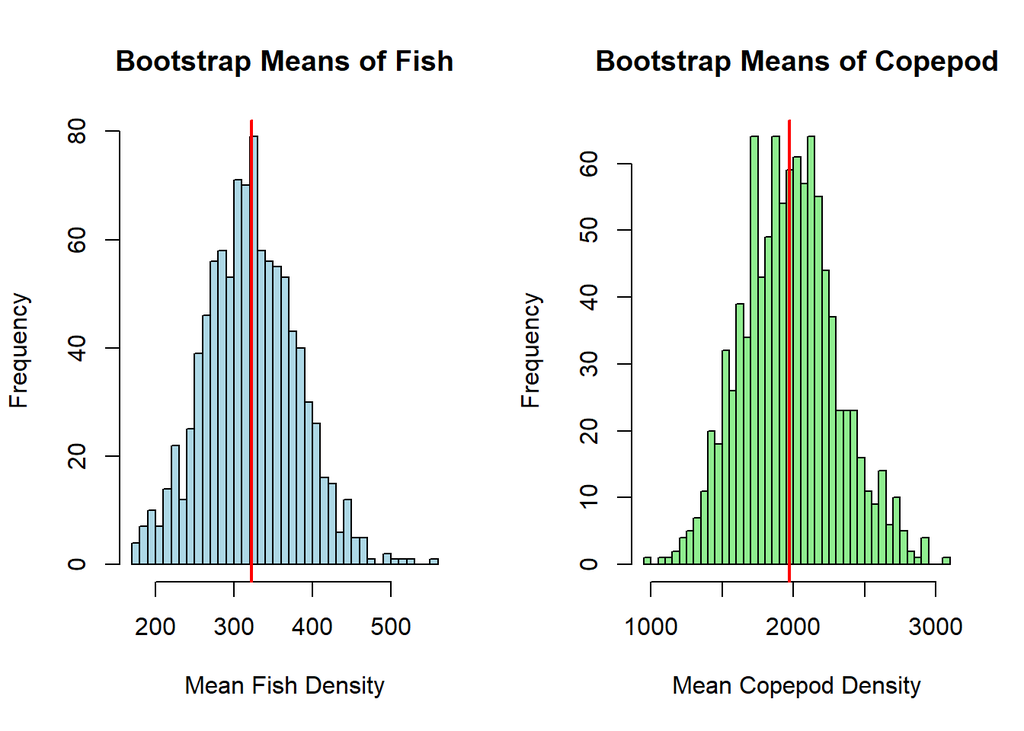

```r
par(mfrow=c(1,2))  # Set up a 1x2 plotting area


hist(boot_means_fish, main="Bootstrap Means of Fish",
     xlab="Mean Fish Density", col="lightblue", breaks=30)
abline(v=mean_fish, col="red", lwd=2)

hist(boot_means_copepod, main="Bootstrap Means of Copepod",
     xlab="Mean Copepod Density", col="lightgreen", breaks=30)
abline(v=mean_copepod, col="red", lwd=2)
```

2. Compute the median and bootstrapped SE(median) for the fish and copepod densities. Plot the histogram of bootstrapped medians with bootstrap 1000 times.

```r
# Compute the median of the original data
median_fish <- median(fish)
median_copepod <- median(copepod)

# Print original median values
print("Original Median Values:")
```

```
## [1] "Original Median Values:"
```

```r
print(paste("Fish: Median =", median_fish))
```

```
## [1] "Fish: Median = 142.9265688"
```

```r
print(paste("Copepod: Median =", median_copepod))
```

```
## [1] "Copepod: Median = 1352.5"
```

```r
# Set bootstrap parameters
B <- 1000  # Number of bootstrap iterations
n <- length(fish)  # Sample size

# Create vectors to store bootstrap results
boot_medians_fish <- numeric(B)
boot_medians_copepod <- numeric(B)

# Perform bootstrap resampling without using sample()
for (i in 1:B) {
  sample_indices <- floor(runif(n, min = 1, max = n + 1))  # Generate random indices between 1 and n
  boot_medians_fish[i] <- median(fish[sample_indices])  # Compute median for resampled fish data, similar to Q.1
  boot_medians_copepod[i] <- median(copepod[sample_indices])  # Compute median for resampled copepod data
}

# Compute bootstrap standard errors (SE)
se_boot_median_fish <- sd(boot_medians_fish)
se_boot_median_copepod <- sd(boot_medians_copepod)

# Print the results
print("Bootstrap estimates for Median:")
```

```
## [1] "Bootstrap estimates for Median:"
```

```r
print(paste("Fish: Median =", median_fish, "SE =", se_boot_median_fish))
```

```
## [1] "Fish: Median = 142.9265688 SE = 96.0807737374875"
```

```r
print(paste("Copepod: Median =", median_copepod, "SE =", se_boot_median_copepod))
```

```
## [1] "Copepod: Median = 1352.5 SE = 197.004599842031"
```

Plot histograms of bootstrapped medians

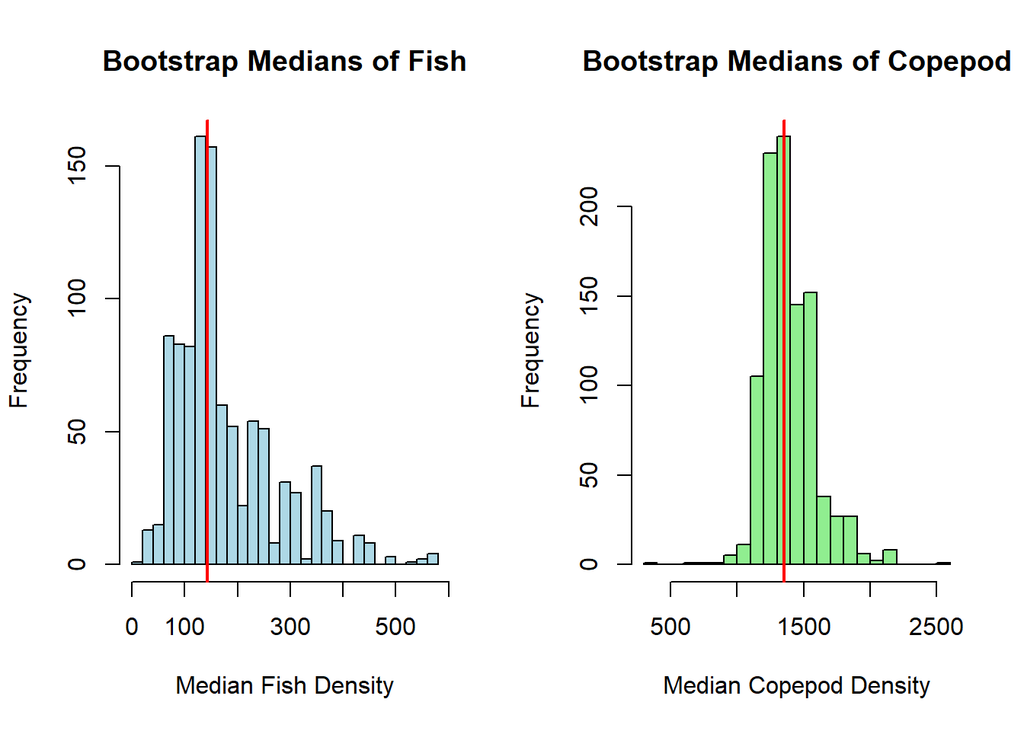

```r
par(mfrow=c(1,2))  # Set up a 1x2 plotting area

# Histogram for fish bootstrap medians
hist(boot_medians_fish, main="Bootstrap Medians of Fish",
     xlab="Median Fish Density", col="lightblue", breaks=30)
abline(v=median_fish, col="red", lwd=2)

# Histogram for copepod bootstrap medians
hist(boot_medians_copepod, main="Bootstrap Medians of Copepod",
     xlab="Median Copepod Density", col="lightgreen", breaks=30)
abline(v=median_copepod, col="red", lwd=2)
```

3. Plot fish (dependent) v.s copepod (independent) and the regression line. Compute the regression coefficients for fish = b0+b1*copepod and bootstrapped SE(b0) and SE(b1). Plot the histogram of bootstrapped b0 and b1 with bootstrap 1000 times.

```r
# Compute linear regression coefficients
model <- lm(fish ~ copepod)  #lm: linear model, with fish as the dependent variable and copepod as the independent variable
b0 <- coef(model)[1]  # Extract the intercept (b0) from the regression model
b1 <- coef(model)[2]  # Extract the slope (b1) from the regression model


print("Original Regression Coefficients:")
```

```
## [1] "Original Regression Coefficients:"
```

```r
print(paste("b0 =", b0))
```

```
## [1] "b0 = 93.0646558597569"
```

```r
print(paste("b1 =", b1))
```

```
## [1] "b1 = 0.116299932859911"
```

bootstrapped SE(b0) and SE(b1)

```r
# Bootstrap settings
B <- 1000
n <- length(fish)

boot_b0 <- numeric(B)
boot_b1 <- numeric(B)

# Bootstrap loop
for (i in 1:B) {
  sample_indices <- floor(runif(n, min = 1, max = n + 1)) # Generate n random indices for sampling
  boot_model <- lm(fish[sample_indices] ~ copepod[sample_indices]) # Create a new linear regression model with bootstrapped samples
  boot_b0[i] <- coef(boot_model)[1] #accumulate the results of bootstrap regression coefficients into vectors boot_b0 & b1
  boot_b1[i] <- coef(boot_model)[2]
}

# Compute bootstrap SE
se_boot_b0 <- sd(boot_b0)
se_boot_b1 <- sd(boot_b1)

print("Bootstrap estimates for Regression Coefficients:")
```

```
## [1] "Bootstrap estimates for Regression Coefficients:"
```

```r
print(paste("b0: SE =", se_boot_b0))
```

```
## [1] "b0: SE = 61.235467108854"
```

```r
print(paste("b1: SE =", se_boot_b1))
```

```
## [1] "b1: SE = 0.0313972449416273"
```

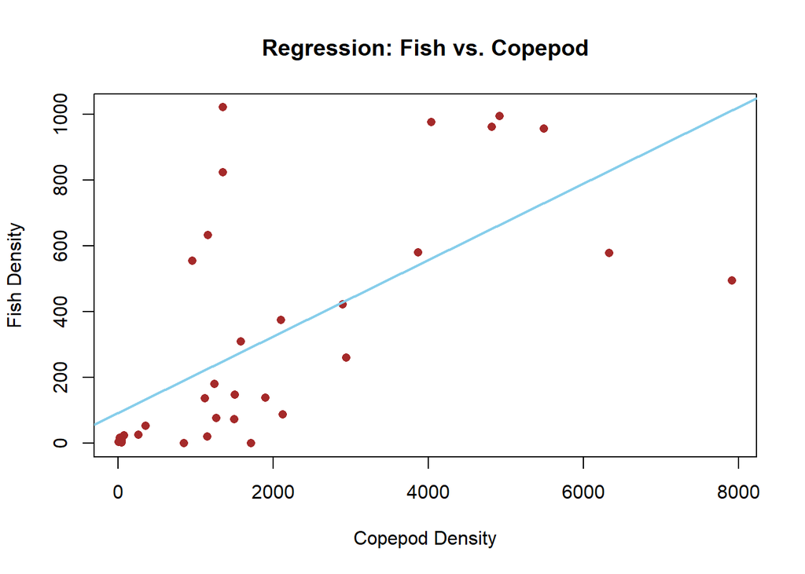

```r
# Plot regression line
plot(copepod, fish, main = "Regression: Fish vs. Copepod",
     xlab = "Copepod Density", ylab = "Fish Density", col = "brown", pch = 16)
abline(b0, b1, col = "skyblue", lwd = 2)
```

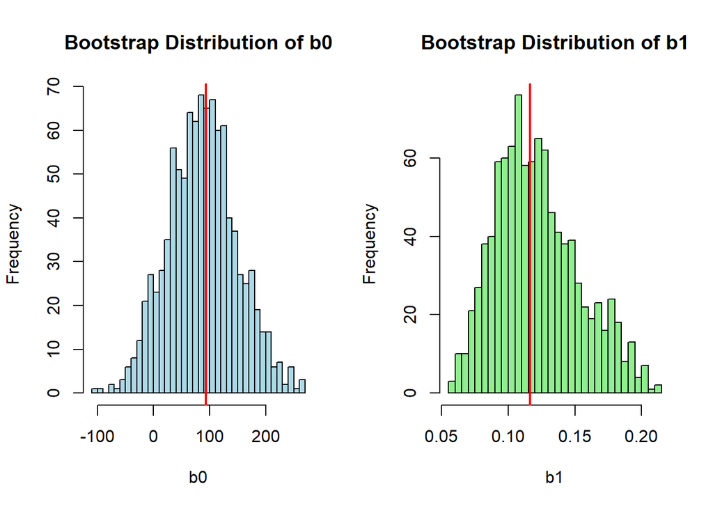

```r
# Plot histograms of bootstrapped coefficients
par(mfrow = c(1, 2))

hist(boot_b0, main = "Bootstrap Distribution of b0",
     xlab = "b0", col = "lightblue", breaks = 30)
abline(v = b0, col = "red", lwd = 2)

hist(boot_b1, main = "Bootstrap Distribution of b1",
     xlab = "b1", col = "lightgreen", breaks = 30)
abline(v = b1, col = "red", lwd = 2)
```

1. Compute the mean and stand error of the mean for the fish and copepod density (all data points) respectively using Jackknife. Plot the histogram of Jackknife means.

```r
# Jackknife function to compute mean and standard error
jackknife_mean <- function(data) {

  n <- length(data)  # Get the number of data points
  jackknife_means <- numeric(n)  # Create a numeric vector to store the mean after removing each data point.

# Loop through each data point, leaving one out at a time
  for (i in 1:n) {
    jackknife_means[i] <- mean(data[-i])  # Compute mean after leaving out the i-th data point
  }

  jackknife_mean <- mean(jackknife_means)  # Compute the mean of all leave-one-out means
  jackknife_se <- sqrt((n - 1) / n * sum((jackknife_means - jackknife_mean)^2))  # Compute Jackknife standard error (SE)
  return(list(means = jackknife_means, mean = jackknife_mean, se = jackknife_se))
}

# Calculate for fish and copepod densities
fish_jackknife <- jackknife_mean(fish)
copepod_jackknife <- jackknife_mean(copepod)

# Print results
print(paste("Fish: Jackknife Mean =", round(fish_jackknife$mean, 2), "Jackknife SE =", round(fish_jackknife$se, 2)))
```

```
## [1] "Fish: Jackknife Mean = 322.45 Jackknife SE = 61.23"
```

```r
print(paste("Copepod: Jackknife Mean =", round(copepod_jackknife$mean, 2), "Jackknife SE =", round(copepod_jackknife$se, 2)))
```

```
## [1] "Copepod: Jackknife Mean = 1972.37 Jackknife SE = 342.55"
```

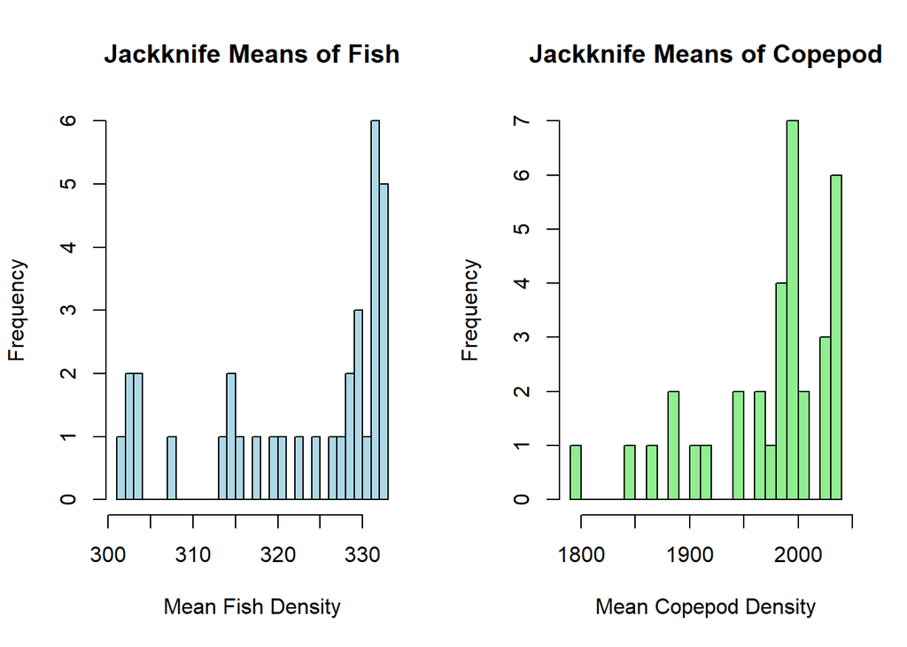

```r
# Plot histograms of Jackknife means
par(mfrow=c(1,2))  # Set up a 1x2 plotting area
hist(fish_jackknife$means, main="Jackknife Means of Fish", xlab="Mean Fish Density", col="lightblue", breaks=30)
hist(copepod_jackknife$means, main="Jackknife Means of Copepod", xlab="Mean Copepod Density", col="lightgreen", breaks=30)
```

2. Compute the regression coefficients for fish = b0+b1*copepod and Jackknife SE of b0 and b1. Plot the histogram of Jackknife b0 and b1.

```r
# Jackknife function to compute regression coefficients (b0 and b1)

jackknife_regression <- function(fish, copepod) {

  n <- length(fish) # Get the number of data points
  jack_b0 <- numeric(n)  # Initialize vector to store leave-one-out b0 (intercept)
  jack_b1 <- numeric(n)  # Initialize vector to store leave-one-out b1 (slope)

  for (i in 1:n) {
    # Create the jackknife sample (leave out the i-th data point)
    jackknife_fish <- fish[-i] # Remove the i-th fish data point
    jackknife_copepod <- copepod[-i] # Remove the corresponding copepod data point

    # Fit the linear model on the remaining data
    model <- lm(jackknife_fish ~ jackknife_copepod) # Perform linear regression
    jack_b0[i] <- coef(model)[1]  # Store b0 (intercept)
    jack_b1[i] <- coef(model)[2]  # Store b1 (slope)
  }

  jackknife_b0 <- mean(jack_b0)  # Jackknife estimate of b0
  jackknife_b1 <- mean(jack_b1)  # Jackknife estimate of b1

  se_b0 <- sqrt((n - 1) / n * sum((jack_b0 - jackknife_b0)^2))  # Jackknife SE for b0
  se_b1 <- sqrt((n - 1) / n * sum((jack_b1 - jackknife_b1)^2))  # Jackknife SE for b1

  return(list(b0 = jackknife_b0, b1 = jackknife_b1, se_b0 = se_b0, se_b1 = se_b1, jack_b0 = jack_b0, jack_b1 = jack_b1))
}

# Calculate for fish and copepod densities
regression_jackknife <- jackknife_regression(fish, copepod)

# Print results
print(paste("Jackknife b0 =", round(regression_jackknife$b0, 2), "SE(b0) =", round(regression_jackknife$se_b0, 2)))
```

```
## [1] "Jackknife b0 = 92.73 SE(b0) = 69.27"
```

```r
print(paste("Jackknife b1 =", round(regression_jackknife$b1, 2), "SE(b1) =", round(regression_jackknife$se_b1, 2)))
```

```
## [1] "Jackknife b1 = 0.12 SE(b1) = 0.04"
```

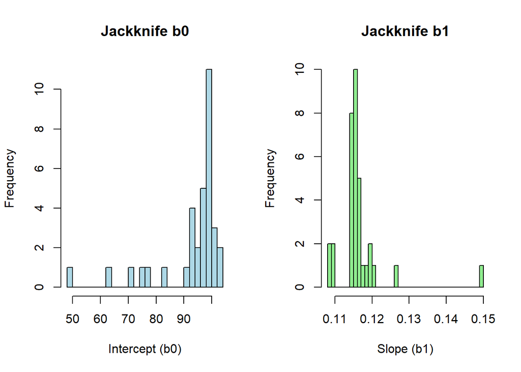

```r
# Extract jackknife estimates for histogram plotting
jack_b0 <- regression_jackknife$jack_b0
jack_b1 <- regression_jackknife$jack_b1

# Plot histograms of Jackknife b0 and b1
par(mfrow=c(1,2))  # Set up a 1x2 plotting area
hist(jack_b0, main="Jackknife b0", xlab="Intercept (b0)", col="lightblue", breaks=30)
hist(jack_b1, main="Jackknife b1", xlab="Slope (b1)", col="lightgreen", breaks=30)
```

3. Compare the estimates for Q1 and Q2 obtained from normal theory, bootstrap, and jackknife.

```r
comparison_table <- data.frame(
  Method = c("Normal Theory", "Bootstrap", "Jackknife"),
  Fish_Mean = c(mean_fish, mean(boot_means_fish), fish_jackknife$mean),
  Fish_SE = c(se_fish, se_boot_fish, fish_jackknife$se),
  Copepod_Mean = c(mean_copepod, mean(boot_means_copepod), copepod_jackknife$mean),
  Copepod_SE = c(se_copepod, se_boot_copepod, copepod_jackknife$se),
  b0 = c(b0, mean(boot_b0), regression_jackknife$b0),
  SE_b0 = c(NA, se_boot_b0, regression_jackknife$se_b0),
  b1 = c(b1, mean(boot_b1), regression_jackknife$b1),
  SE_b1 = c(NA, se_boot_b1, regression_jackknife$se_b1)
)

print(comparison_table)
```

```
##          Method Fish_Mean  Fish_SE Copepod_Mean Copepod_SE       b0    SE_b0
## 1 Normal Theory  322.4516 61.23107     1972.374   342.5549 93.06466       NA
## 2     Bootstrap  322.2182 59.07904     1973.781   330.5700 87.72064 61.23547
## 3     Jackknife  322.4516 61.23107     1972.374   342.5549 92.73093 69.27329
##          b1      SE_b1
## 1 0.1162999         NA
## 2 0.1216731 0.03139724
## 3 0.1165492 0.03800030
```